# Assignment 8: Exploratory factor analysis

DA 410

Marjorie Blanco

13.7 Use the words data of Table 5.9.

1. Obtain principal component loadings for two factors.

You may use R to solve this part (NO built-in function). Follow the 5-steps of the example introduced in the handout to obtain principal component loadings for two factors. Make sure to show your work completely.

```r
data <-read.table("Software-Files/T5_9_ESSAY.DAT")
colnames(data) <- c("student" ,"Informal words", "Informal verbs",
                    "Formal words", "Formal verbs")
data <- data[,2:5]
```

## Bartlett’s Test of Sphericity

```r
cortest.bartlett(data)
```

```
## R was not square, finding R from data
```

```
## $chisq
## [1] 29.27297
##
## $p.value
## [1] 5.401014e-05
##
## $df
## [1] 6
```

Bartlett’s test was statistically significant, suggesting that the observed correlation matrix among the items is not an identity matrix.

## KMO

```r
KMO(data)
```

```
## Kaiser-Meyer-Olkin factor adequacy
## Call: KMO(r = data)
## Overall MSA =  0.5
## MSA for each item =
## Informal words Informal verbs   Formal words   Formal verbs
##           0.45           0.58           0.55           0.41
```

The overall KMO for our data is 0.5.

Step 1: Find correlation matrix R.

```r
n <- nrow(data)
C <- diag(n) - matrix(1/n, n, n)
D <- diag(apply(as.matrix(data), 2, sd))
Xs <- C %*% as.matrix(data) %*% solve(D)
R <- t(Xs) %*% Xs / (n-1)
```

```r
rownames(R) <- colnames(R) <- colnames(data)
```

R=

|  | Informal words | Informal verbs | Formal words | Formal verbs |
| --- | --- | --- | --- | --- |
| Informal words | 1.0000000 | 0.7660725 | 0.5953551 | 0.2173378 |
| Informal verbs | 0.7660725 | 1.0000000 | 0.5600505 | 0.4427548 |
| Formal words | 0.5953551 | 0.5600505 | 1.0000000 | 0.7202028 |
| Formal verbs | 0.2173378 | 0.4427548 | 0.7202028 | 1.0000000 |

```r
# Calculate the correlation matrix
res.cor <- cor(data)
```

R=

|  | Informal words | Informal verbs | Formal words | Formal verbs |
| --- | --- | --- | --- | --- |
| Informal words | 1.0000000 | 0.7660725 | 0.5953551 | 0.2173378 |
| Informal verbs | 0.7660725 | 1.0000000 | 0.5600505 | 0.4427548 |
| Formal words | 0.5953551 | 0.5600505 | 1.0000000 | 0.7202028 |
| Formal verbs | 0.2173378 | 0.4427548 | 0.7202028 | 1.0000000 |

```r
n <- nrow(data)
C <- diag(n) - matrix(1/n, n, n)
Xc <- C %*% as.matrix(data)
S <- t(Xc) %*% Xc / (n-1)
```

S=

|  | Informal words | Informal verbs | Formal words | Formal verbs |
| --- | --- | --- | --- | --- |
| Informal words | 1405.78095 | 153.70952 | 804.7667 | 43.10476 |
| Informal verbs | 153.70952 | 28.63810 | 108.0524 | 12.53333 |
| Formal words | 804.76667 | 108.05238 | 1299.7810 | 137.34762 |
| Formal verbs | 43.10476 | 12.53333 | 137.3476 | 27.98095 |

```r
res.cov <- cov(data)
```

S=

|  | Informal words | Informal verbs | Formal words | Formal verbs |
| --- | --- | --- | --- | --- |
| Informal words | 1405.78095 | 153.70952 | 804.7667 | 43.10476 |
| Informal verbs | 153.70952 | 28.63810 | 108.0524 | 12.53333 |
| Formal words | 804.76667 | 108.05238 | 1299.7810 | 137.34762 |
| Formal verbs | 43.10476 | 12.53333 | 137.3476 | 27.98095 |

Step 2: Find the eigenvalue D and eigenvectors C of R.

```r
# Then use that correlation matrix to calculate eigenvalues
res.eig <- eigen(res.cor, symmetric = FALSE)
res.eig
```

```
## eigen() decomposition
## $values
## [1] 2.6657459 0.8993358 0.3276382 0.1072801
##
## $vectors
##           [,1]       [,2]       [,3]       [,4]
## [1,] 0.4914201  0.5642628 -0.3208298  0.5806737
## [2,] 0.5241023  0.3441774  0.6604771 -0.4130722
## [3,] 0.5409202 -0.2848265 -0.6020434 -0.5136371
## [4,] 0.4372967 -0.6942790  0.3136590  0.4778769
```

Step 3: Find $C_1$ and $D_1$

```r
c.1 <- res.eig$vectors[,1:2]
d.1 <- diag(res.eig$values[1:2])
```

$C_1$=

| 0.4914201 | 0.5642628 |
| --- | --- |
| 0.5241023 | 0.3441774 |
| 0.5409202 | -0.2848265 |
| 0.4372967 | -0.6942790 |

$D_1$=

| 2.665746 | 0.0000000 |
| --- | --- |
| 0.000000 | 0.8993358 |

Step 4: Find $C_1D^{1/2}_1$

```r
l <- as.data.frame(c.1 %*% sqrt(d.1))
```

$C_1D^{1/2}_1$=

| V1 | V2 |
| --- | --- |
| 0.8023471 | 0.5351091 |
| 0.8557077 | 0.3263949 |
| 0.8831664 | -0.2701104 |
| 0.7139792 | -0.6584078 |

Step 5: Obtain loadings

```r
l[,3] <- l[,1]^2 + l[,2]^2
l[,4] <- 1 - l[,3]
```

|  | Principal Component Loadings f1 | Principal Component Loadings f2 | Communalities | u |
| --- | --- | --- | --- | --- |
| Informal words | 0.802 | 0.535 | 0.930 | 0.070 |
| Informal verbs | 0.856 | 0.326 | 0.839 | 0.161 |
| Formal words | 0.883 | -0.270 | 0.853 | 0.147 |
| Formal verbs | 0.714 | -0.658 | 0.943 | 0.057 |

```r
prop <- res.eig$values[1:2]/sum(res.eig$values)
cumprop <- c(prop[1], sum(prop))
```

Variance accounted for 2.6657459, 0.8993358 3.5650817

Proportion accounted for 0.6664365, 0.224834 0.8912704

Cumulative proportion 0.6664365, 0.8912704 0.8912704

The first two factors account for ( 2.6657 + 0.8993)/4 = 0.89 of the total sample variance. 89.13 % of the variance explained by two factors is very high.

Informal words, Informal words, Formal words all have high factor loadings around 0.8 on the first factor (PC1).

```r
pc <- principal(data, nfactors = 2, rotate = 'none', covar = FALSE)
pc
```

```
## Principal Components Analysis
## Call: principal(r = data, nfactors = 2, rotate = "none", covar = FALSE)
## Standardized loadings (pattern matrix) based upon correlation matrix
##                 PC1   PC2   h2    u2 com
## Informal words 0.80 -0.54 0.93 0.070 1.7
## Informal verbs 0.86 -0.33 0.84 0.161 1.3
## Formal words   0.88  0.27 0.85 0.147 1.2
## Formal verbs   0.71  0.66 0.94 0.057 2.0
##
##                        PC1  PC2
## SS loadings           2.67 0.90
## Proportion Var        0.67 0.22
## Cumulative Var        0.67 0.89
## Proportion Explained  0.75 0.25
## Cumulative Proportion 0.75 1.00
##
## Mean item complexity =  1.6
## Test of the hypothesis that 2 components are sufficient.
##
## The root mean square of the residuals (RMSR) is  0.07
##  with the empirical chi square  0.95  with prob <  NA
##
## Fit based upon off diagonal values = 0.98
```

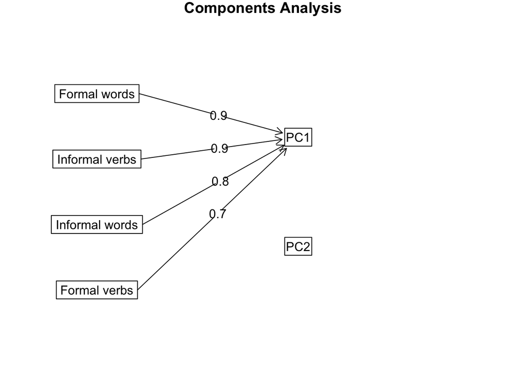

```r
fa.diagram(pc)
```

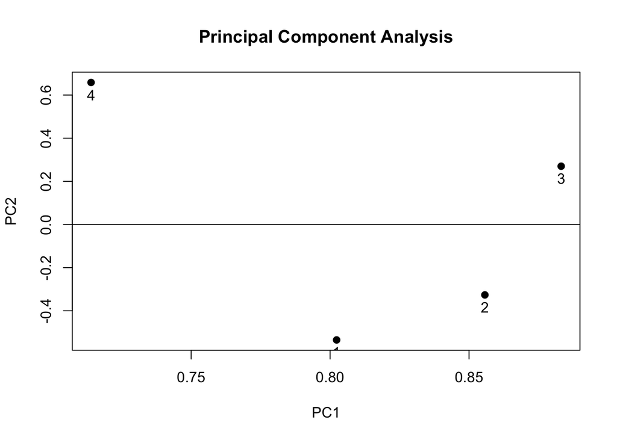

```r
plot(pc)
```

```r
R <- cor(data)
round(R, 2)
```

```
##                Informal words Informal verbs Formal words Formal verbs
## Informal words           1.00           0.77         0.60         0.22
## Informal verbs           0.77           1.00         0.56         0.44
## Formal words             0.60           0.56         1.00         0.72
## Formal verbs             0.22           0.44         0.72         1.00
```

```r
r.eigen <- eigen(R, symmetric=FALSE)
r.eigen
```

```
## eigen() decomposition
## $values
## [1] 2.6657459 0.8993358 0.3276382 0.1072801
##
## $vectors
##           [,1]       [,2]       [,3]       [,4]
## [1,] 0.4914201  0.5642628 -0.3208298  0.5806737
## [2,] 0.5241023  0.3441774  0.6604771 -0.4130722
## [3,] 0.5409202 -0.2848265 -0.6020434 -0.5136371
## [4,] 0.4372967 -0.6942790  0.3136590  0.4778769
```

```r
cumulative.proportion <- 0
prop <- c()
cumulative <- c()
for (i in r.eigen$values) {
  proportion <- i / dim(data)[2]
  cumulative.proportion <- cumulative.proportion + proportion

  prop <- append(prop, proportion)
  cumulative <- append(cumulative, cumulative.proportion)
}
data.frame(cbind(prop, cumulative))
```

```
##         prop cumulative
## 1 0.66643647  0.6664365
## 2 0.22483396  0.8912704
## 3 0.08190955  0.9731800
## 4 0.02682002  1.0000000
```

```r
factors <- t(t(r.eigen$vectors[,1:2]) * sqrt(r.eigen$values[1:2]))
round(factors, 2)
```

```
##      [,1]  [,2]
## [1,] 0.80  0.54
## [2,] 0.86  0.33
## [3,] 0.88 -0.27
## [4,] 0.71 -0.66
```

```r
h2 <- rowSums(factors^2)
h2
```

```
## [1] 0.9301027 0.8387693 0.8529425 0.9432671
```

```r
u2 <- 1 - h2
u2
```

```
## [1] 0.06989729 0.16123067 0.14705746 0.05673285
```

```r
com <- rowSums(factors^2)^2 / rowSums(factors^4)
com
```

```
## [1] 1.742660 1.284950 1.185457 1.987011
```

```r
mean(com)
```

```
## [1] 1.55002
```

```r
fa <- principal(data, nfactors = 2, rotate = 'none')
fa
```

```
## Principal Components Analysis
## Call: principal(r = data, nfactors = 2, rotate = "none")
## Standardized loadings (pattern matrix) based upon correlation matrix
##                 PC1   PC2   h2    u2 com
## Informal words 0.80 -0.54 0.93 0.070 1.7
## Informal verbs 0.86 -0.33 0.84 0.161 1.3
## Formal words   0.88  0.27 0.85 0.147 1.2
## Formal verbs   0.71  0.66 0.94 0.057 2.0
##
##                        PC1  PC2
## SS loadings           2.67 0.90
## Proportion Var        0.67 0.22
## Cumulative Var        0.67 0.89
## Proportion Explained  0.75 0.25
## Cumulative Proportion 0.75 1.00
##
## Mean item complexity =  1.6
## Test of the hypothesis that 2 components are sufficient.
##
## The root mean square of the residuals (RMSR) is  0.07
##  with the empirical chi square  0.95  with prob <  NA
##
## Fit based upon off diagonal values = 0.98
```

Decide how many factors to retain.

For the probe data set, I recomend to retain 1 factor

### Method 1: Choose m equal to the number of factors necessary for the variance accounted for to achieve a predetermined percentage

An appropriate threshold percentage should be selected prior to starting the process. If we want to explain at least 70% of variance then we would select $f1$ and $f2$

### Method 3: Scree plot

The number of points after point of inflexion. For this plot, retaining $f1$ is recomended.

```r
parallel <- fa.parallel(data, fm = 'minres', fa = 'fa')
```

[figure not shown]

```
## Parallel analysis suggests that the number of factors =  1  and the number of components =  NA
```